# Описание проекта

Cтартапу, который продаёт продукты питания, нужно разобраться, как ведут себя пользователи мобильного приложения. Для этого необходимо:

- изучить воронку продаж. Узнать, как пользователи доходят до покупки. Сколько пользователей доходит до покупки, а сколько — «застревает» на предыдущих шагах? На каких именно?
- исследовать результаты A/A/B-эксперимента. Дизайнеры захотели поменять шрифты во всём приложении, а менеджеры испугались, что пользователям будет непривычно. Договорились принять решение по результатам A/A/B-теста. Пользователей разбили на 3 группы: 2 контрольные со старыми шрифтами и одну экспериментальную — с новыми. Выяснить, какой шрифт лучше.

Описание данных:

- EventName — название события;
- DeviceIDHash — уникальный идентификатор пользователя;
- EventTimestamp — время события;
- ExpId — номер эксперимента: 246 и 247 — контрольные группы, а 248 — экспериментальная.

Каждая запись в логе — это действие пользователя, или событие.

План работы:

1. Подготовить данные
- Заменить названия столбцов на удобные;
- Проверить пропуски и типы данных. Откорректировать, если нужно;
- Добавить столбец даты и времени, а также отдельный столбец дат;
- Проверить на наличие пропусков и дубликатов. Удалить дубликаты, если будут.
2. Изучить и проверить данные
- Определить сколько всего событий и пользователей в логе.
- Определить сколько в среднем событий приходится на пользователя.
- Определить, за какой период собраны данные в датафрейме. Найти максимальную и минимальную дату. Изучить, как меняется количество данных: построить столбчатую диаграмму, которая отобразит количество событий в зависимости от времени в разрезе групп.
- Определите, с какого момента данные полные и отбросьте более старые. Данными за какой период времени вы располагаете на самом деле.
- Определить, сколько событий и пользователей были отброшены в старых данных.
- Проверить, что есть пользователи из всех трёх экспериментальных групп.
3. Изучить воронку событий
- Посмотреть, какие события есть в логах, как часто они встречаются. Отсортировать события по частоте.
- Посчитать, сколько пользователей совершали каждое из этих событий. Отсортировать события по числу пользователей. Посчитать долю пользователей, которые хоть раз совершали событие.
- Предположить, в каком порядке происходят события. Все ли они выстраиваются в последовательную цепочку?
- По воронке событий посчитать, какая доля пользователей проходит на следующий шаг воронки (от числа пользователей на предыдущем). То есть для последовательности событий A → B → C посчитать отношение числа пользователей с событием B к количеству пользователей с событием A, а также отношение числа пользователей с событием C к количеству пользователей с событием B.
- Определить на каком шаге теряете больше всего пользователей.
- Определить какая доля пользователей доходит от первого события до оплаты.
4. Изучить результаты эксперимента
- Определить сколько пользователей в каждой экспериментальной группе.
- Есть 2 контрольные группы для А/А-эксперимента, чтобы проверить корректность всех механизмов и расчётов. Проверить, находят ли статистические критерии разницу между выборками 246 и 247.
- Выберать самое популярное событие. Посчитать число пользователей, совершивших это событие в каждой из контрольных групп. Посчитать долю пользователей, совершивших это событие. Проверить, будет ли отличие между группами статистически достоверным. Проделать то же самое для всех других событий (удобно обернуть проверку в отдельную функцию). Можно ли сказать, что разбиение на группы работает корректно?
- Аналогично поступить с группой с изменённым шрифтом. Сравнить результаты с каждой из контрольных групп в отдельности по каждому событию. Сравнить результаты с объединённой контрольной группой. Сделать выводы.
- При уровне значимости 0.1 в 10% случаев можно ошибочно отклонить нулевую гипотезу при условии, что она верна. Какой уровень значимости стоит применить?

Для начала загрузим необходимые библиотеки

```python
import pandas as pd
import datetime as dt
import numpy as np
import matplotlib.pyplot as plt
import math as mth
from scipy import stats as st
from plotly import graph_objects as go
```

```python
# выставляем ограничение на показ знаков после запятой
pd.options.display.float_format = '{:,.2f}'.format
```

## Откроем файл с данными и изучим общую информацию

```python
data = pd.read_csv('/datasets/logs_exp.csv', sep='\t')
display(data.head(5))
data.info()
```

|  | EventName | DeviceIDHash | EventTimestamp | ExpId |
| --- | --- | --- | --- | --- |
| 0 | MainScreenAppear | 4575588528974610257 | 1564029816 | 246 |
| 1 | MainScreenAppear | 7416695313311560658 | 1564053102 | 246 |
| 2 | PaymentScreenSuccessful | 3518123091307005509 | 1564054127 | 248 |
| 3 | CartScreenAppear | 3518123091307005509 | 1564054127 | 248 |
| 4 | PaymentScreenSuccessful | 6217807653094995999 | 1564055322 | 248 |

```
<class 'pandas.core.frame.DataFrame'>
RangeIndex: 244126 entries, 0 to 244125
Data columns (total 4 columns):
 #   Column          Non-Null Count   Dtype
---  ------          --------------   -----
 0   EventName       244126 non-null  object
 1   DeviceIDHash    244126 non-null  int64
 2   EventTimestamp  244126 non-null  int64
 3   ExpId           244126 non-null  int64
dtypes: int64(3), object(1)
memory usage: 7.5+ MB
```

## Подготовим данные

### Заменим названия столбцов на удобные для работы

```python
data = data.rename(columns = {'EventName': 'event_name', 'DeviceIDHash': 'device_id', 'EventTimestamp': 'event_time_stamp', 'ExpId': 'exp_id'})
display(data.head(5))
```

|  | event_name | device_id | event_time_stamp | exp_id |
| --- | --- | --- | --- | --- |
| 0 | MainScreenAppear | 4575588528974610257 | 1564029816 | 246 |
| 1 | MainScreenAppear | 7416695313311560658 | 1564053102 | 246 |
| 2 | PaymentScreenSuccessful | 3518123091307005509 | 1564054127 | 248 |
| 3 | CartScreenAppear | 3518123091307005509 | 1564054127 | 248 |
| 4 | PaymentScreenSuccessful | 6217807653094995999 | 1564055322 | 248 |

### Проверим пропуски и типы данных

Из общей информации выше видно, что пропусков в столбцах нет. У столбца event_time_stamp тип данных необходимо поменять из int64 в data.

```python
data['event_time_stamp']=pd.to_datetime(data['event_time_stamp'], unit='s')
display(data.head(5))
data.info()
```

|  | event_name | device_id | event_time_stamp | exp_id |
| --- | --- | --- | --- | --- |
| 0 | MainScreenAppear | 4575588528974610257 | 2019-07-25 04:43:36 | 246 |
| 1 | MainScreenAppear | 7416695313311560658 | 2019-07-25 11:11:42 | 246 |
| 2 | PaymentScreenSuccessful | 3518123091307005509 | 2019-07-25 11:28:47 | 248 |
| 3 | CartScreenAppear | 3518123091307005509 | 2019-07-25 11:28:47 | 248 |
| 4 | PaymentScreenSuccessful | 6217807653094995999 | 2019-07-25 11:48:42 | 248 |

```
<class 'pandas.core.frame.DataFrame'>
RangeIndex: 244126 entries, 0 to 244125
Data columns (total 4 columns):
 #   Column            Non-Null Count   Dtype
---  ------            --------------   -----
 0   event_name        244126 non-null  object
 1   device_id         244126 non-null  int64
 2   event_time_stamp  244126 non-null  datetime64[ns]
 3   exp_id            244126 non-null  int64
dtypes: datetime64[ns](1), int64(2), object(1)
memory usage: 7.5+ MB
```

### Добавим столбец отдельный столбец дат

```python
data['event_day']=pd.DatetimeIndex(data['event_time_stamp']).date
display(data.head(5))
```

|  | event_name | device_id | event_time_stamp | exp_id | event_day |
| --- | --- | --- | --- | --- | --- |
| 0 | MainScreenAppear | 4575588528974610257 | 2019-07-25 04:43:36 | 246 | 2019-07-25 |
| 1 | MainScreenAppear | 7416695313311560658 | 2019-07-25 11:11:42 | 246 | 2019-07-25 |
| 2 | PaymentScreenSuccessful | 3518123091307005509 | 2019-07-25 11:28:47 | 248 | 2019-07-25 |
| 3 | CartScreenAppear | 3518123091307005509 | 2019-07-25 11:28:47 | 248 | 2019-07-25 |
| 4 | PaymentScreenSuccessful | 6217807653094995999 | 2019-07-25 11:48:42 | 248 | 2019-07-25 |

### Проверим наличие дубликатов

```python
data.duplicated().sum()
```

```
413
```

### Удалим дубликаты

```python
data = data.drop_duplicates()
data.info()
```

```
<class 'pandas.core.frame.DataFrame'>
Int64Index: 243713 entries, 0 to 244125
Data columns (total 5 columns):
 #   Column            Non-Null Count   Dtype
---  ------            --------------   -----
 0   event_name        243713 non-null  object
 1   device_id         243713 non-null  int64
 2   event_time_stamp  243713 non-null  datetime64[ns]
 3   exp_id            243713 non-null  int64
 4   event_day         243713 non-null  object
dtypes: datetime64[ns](1), int64(2), object(2)
memory usage: 11.2+ MB
```

### Изменим тип данных в толбце event_day с object на date

```python
data['event_day'] = pd.to_datetime(data['event_day'], format='%Y-%m-%d')
display(data.head(5))
data.info()
```

|  | event_name | device_id | event_time_stamp | exp_id | event_day |
| --- | --- | --- | --- | --- | --- |
| 0 | MainScreenAppear | 4575588528974610257 | 2019-07-25 04:43:36 | 246 | 2019-07-25 |
| 1 | MainScreenAppear | 7416695313311560658 | 2019-07-25 11:11:42 | 246 | 2019-07-25 |
| 2 | PaymentScreenSuccessful | 3518123091307005509 | 2019-07-25 11:28:47 | 248 | 2019-07-25 |
| 3 | CartScreenAppear | 3518123091307005509 | 2019-07-25 11:28:47 | 248 | 2019-07-25 |
| 4 | PaymentScreenSuccessful | 6217807653094995999 | 2019-07-25 11:48:42 | 248 | 2019-07-25 |

```
<class 'pandas.core.frame.DataFrame'>
Int64Index: 243713 entries, 0 to 244125
Data columns (total 5 columns):
 #   Column            Non-Null Count   Dtype
---  ------            --------------   -----
 0   event_name        243713 non-null  object
 1   device_id         243713 non-null  int64
 2   event_time_stamp  243713 non-null  datetime64[ns]
 3   exp_id            243713 non-null  int64
 4   event_day         243713 non-null  datetime64[ns]
dtypes: datetime64[ns](2), int64(2), object(1)
memory usage: 11.2+ MB
```

## Изучим данные

### Определим сколько всего событий в логе

```python
initial_total_events = data['event_time_stamp'].count()
print('Всего событий в логе', initial_total_events)
print('Уникальные названия событий', data['event_name'].unique())
```

```
Всего событий в логе 243713
Уникальные названия событий ['MainScreenAppear' 'PaymentScreenSuccessful' 'CartScreenAppear'
 'OffersScreenAppear' 'Tutorial']
```

Уникальных событий 5 видов, всего в логе 243 713 событий.

### Определим сколько всего пользователей в логе

```python
initial_users_count = data['device_id'].nunique()
print('Уникальных пользователей в логе', initial_users_count)
```

```
Уникальных пользователей в логе 7551
```

### Определим сколько в среднем событий приходится на пользователя

```python
events_per_user = data.pivot_table(index='device_id', values = 'event_day', aggfunc = 'count').reset_index()
events_per_user.columns = ['device_id', 'event_count']
events_per_user['event_count'].mean()
```

```
32.27559263673685
```

В среднем 32 события приходится на пользователя.

### Найдим максимальную и минимальную дату в датафрейме

```python
print('Минимальная дата:', data['event_time_stamp'].min())
print('Максимальная дата:', data['event_time_stamp'].max())
```

```
Минимальная дата: 2019-07-25 04:43:36
Максимальная дата: 2019-08-07 21:15:17
```

В датафрейме собраны данные с 25 июля по 07 августа 2019 г., период 14 дней.

### Изучим, как меняется количество данных по столбчатой диаграмме, отображающей количество событий в зависимости от времени в разрезе групп

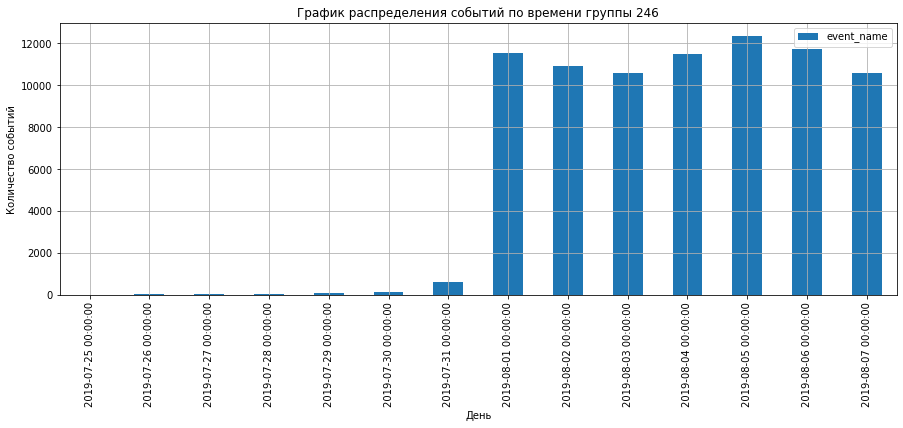

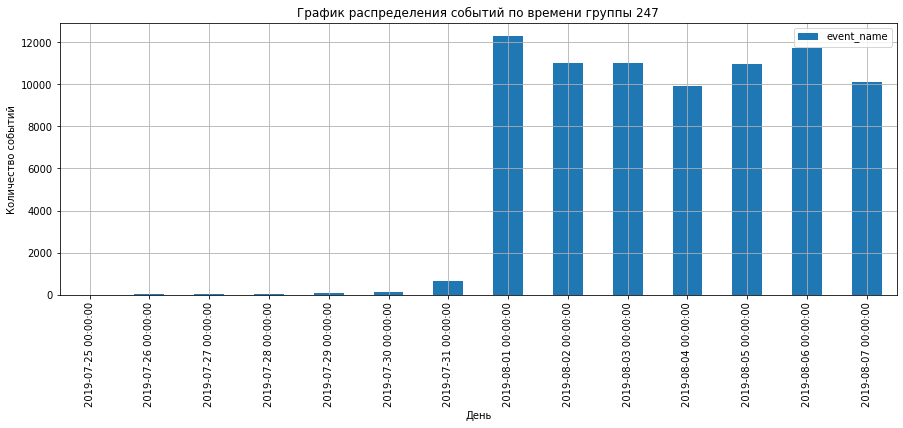

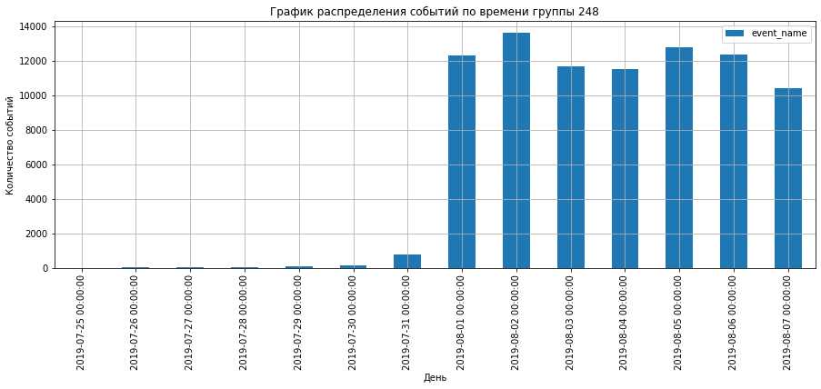

```python
groups = [246, 247, 248]
for i in groups:
    event_count = data.query('exp_id == @i')
    evcount = event_count.pivot_table(index='event_day', values = 'event_name', aggfunc = 'count').reset_index()
    evcount.plot(x='event_day', y='event_name', kind= 'bar', figsize = (15,5), grid = True)
    plt.xticks(rotation='vertical')
    plt.title(f'График распределения событий по времени группы {i}')
    plt.xlabel('День')
    plt.ylabel('Количество событий')
plt.show()
```

Из графиков видно, что данных до 01 августа 2019 г. мало. На самом деле полные данные представлены с 01 августа. Технически в логи новых дней по некоторым пользователям могут «доезжать» события из прошлого — это может «перекашивать данные».

### Для дальнейших расчетов и анализа отбросим данные до 01 авгруста

```python
data = data.query('event_day >= "2019-08-01"')
```

### Посмотрим как много событий и пользователей были отброшены

```python
data.info()

flt_events_count = data['event_time_stamp'].count()
print('Исходное количество событий в логе:', initial_total_events)
print('Оставшееся количество событий в логе:', flt_events_count)
print('Количество отброшенных событий:', initial_total_events-flt_events_count, '({:.1%})'.format((initial_total_events-flt_events_count)/initial_total_events))
flt_users_count = data['device_id'].nunique()
print('Исходное количество пользователей:', initial_users_count)
print('Оставшееся количество пользователей:', flt_users_count)
print('Количество отброшенных пользователей:', initial_users_count-flt_users_count, '({:.1%})'.format((initial_users_count-flt_users_count)/initial_users_count))
```

```
<class 'pandas.core.frame.DataFrame'>
Int64Index: 240887 entries, 2828 to 244125
Data columns (total 5 columns):
 #   Column            Non-Null Count   Dtype
---  ------            --------------   -----
 0   event_name        240887 non-null  object
 1   device_id         240887 non-null  int64
 2   event_time_stamp  240887 non-null  datetime64[ns]
 3   exp_id            240887 non-null  int64
 4   event_day         240887 non-null  datetime64[ns]
dtypes: datetime64[ns](2), int64(2), object(1)
memory usage: 11.0+ MB
Исходное количество событий в логе: 243713
Оставшееся количество событий в логе: 240887
Количество отброшенных событий: 2826 (1.2%)
Исходное количество пользователей: 7551
Оставшееся количество пользователей: 7534
Количество отброшенных пользователей: 17 (0.2%)
```

### Проверим распределение пользователей по трём экспериментальным группам

```python
users_by_groups = data.pivot_table(index='exp_id', values = 'device_id', aggfunc = 'nunique').reset_index()
display(users_by_groups)
```

|  | exp_id | device_id |
| --- | --- | --- |
| 0 | 246 | 2484 |
| 1 | 247 | 2513 |
| 2 | 248 | 2537 |

Распределение пользователей по группам примерно одинаковое.

```python
total_users_246 = users_by_groups.loc[0, 'device_id']
total_users_247 = users_by_groups.loc[1, 'device_id']
total_users_248 = users_by_groups.loc[2, 'device_id']
```

## Изучим воронку событий

### Посмотрим какие события есть в логах, как часто они встречаются. Отсортируем события по частоте.

```python
data.pivot_table(index='event_name', values = 'event_day', aggfunc = 'count').sort_values(by = 'event_day', ascending = False)
```

| event_name | event_day |
| --- | --- |
| MainScreenAppear | 117328 |
| OffersScreenAppear | 46333 |
| CartScreenAppear | 42303 |
| PaymentScreenSuccessful | 33918 |
| Tutorial | 1005 |

### Посчитаем, сколько пользователей совершали каждое из этих событий. Отсортируем события по числу пользователей. Посчитаем долю пользователей, которые хоть раз совершали событие.

```python
event_by_user_count = data.pivot_table(index='event_name', values = 'device_id', aggfunc = 'nunique').sort_values(by = 'device_id', ascending = False).reset_index()
event_by_user_count.columns = ['event_name', 'users_count']
event_by_user_count['users_ratio'] = event_by_user_count['users_count']/flt_users_count
display(event_by_user_count)
```

|  | event_name | users_count | users_ratio |
| --- | --- | --- | --- |
| 0 | MainScreenAppear | 7419 | 0.98 |
| 1 | OffersScreenAppear | 4593 | 0.61 |
| 2 | CartScreenAppear | 3734 | 0.50 |
| 3 | PaymentScreenSuccessful | 3539 | 0.47 |
| 4 | Tutorial | 840 | 0.11 |

98,4% пользователей зашли на главный экран, примерно 47% дошли до экрана с платежом.

### Предположим, в каком порядке происходят события.

Скорее всего путь пользователей начинается с главного экрана, далее они смотрят предложение/католог продуктов питания, что-то из продуктов помещают в корзину и переходят на экран корзины, далее переходят на экран оплаты. На экран Tutorial заходит всего 11 % пользователей. При расчете воронки событие Tutorial учитывать не будем.

### Посчитаем по воронке событий, какая доля пользователей проходит на следующий шаг воронки (от числа пользователей на предыдущем). То есть для последовательности событий A → B → C посчитайте отношение числа пользователей с событием B к количеству пользователей с событием A, а также отношение числа пользователей с событием C к количеству пользователей с событием B.

```python
sales_funnel = event_by_user_count.loc[:3, ['event_name', 'users_count']]

for i in range(sales_funnel.index.max()):
    i += 1
    sales_funnel.loc[i,'ratio_users_next_step'] = sales_funnel.loc[i,'users_count']/sales_funnel.loc[i-1,'users_count']
display(sales_funnel)
```

|  | event_name | users_count | ratio_users_next_step |
| --- | --- | --- | --- |
| 0 | MainScreenAppear | 7419 | NaN |
| 1 | OffersScreenAppear | 4593 | 0.62 |
| 2 | CartScreenAppear | 3734 | 0.81 |
| 3 | PaymentScreenSuccessful | 3539 | 0.95 |

На экран OffersScreenAppear дошли 61.9 % пользователей от количества пользователей с главного экрана, на экран CartScreenAppear долши 81.3 % от количества пользователей с предыдущего шага OffersScreenAppear, до оплаты дошло 94.7 % пользователей с экрана CartScreenAppear.

```python
fig = go.Figure(go.Funnel(
    y = ["MainScreenAppear", "OffersScreenAppear", "CartScreenAppear", "PaymentScreenSuccessful"],
    x = sales_funnel['users_count']))
fig.update_layout(title_text='Воронка событий')
fig.show()
```

[interactive chart not shown]

### На каком шаге теряете больше всего пользователей?

На переходе с главного экрана MainScreenAppear на каталог OffersScreenAppear теряется больше всего пользователей - примерно 40 % пользователей.

### Определим какая доля пользователей доходит от первого события до оплаты

```python
sales_funnel.loc[3,'users_count']/sales_funnel.loc[0,'users_count']
```

```
0.47701846610055265
```

От первого события MainScreenAppear до оплаты PaymentScreenSuccessful доходит 47.7 % пользователей.

## Изучим результаты эксперимента

### Есть 2 контрольные группы для А/А-эксперимента, чтобы проверить корректность всех механизмов и расчётов. Проверьте, находят ли статистические критерии разницу между выборками 246 и 247.

Исключим событие Tutorial из датафрейма и посчитаем количество пользователей по событиям в группах.

```python
data_without_tutorial = data.query('event_name != "Tutorial"')
data_control_groups = data_without_tutorial.query('exp_id != 248')
event_count_control_groups = data_control_groups.pivot_table(index='event_name', columns ='exp_id', values = 'device_id', aggfunc = 'nunique').reset_index()
event_count_control_groups.columns = ['event_name', '246_users_count', '247_users_count']
```

Проверим, принадлежит ли каждый пользователь только одной группе.

```python
flt = data_without_tutorial.groupby('device_id').agg({'exp_id': 'nunique'}).reset_index()
display(flt.query('exp_id > 1'))
```

|  | device_id | exp_id |
| --- | --- | --- |

Каждый пользователь принадлежит только одной группе.

Посчитаем долю пользователей, совершивших это событие и другие.

```python
event_count_control_groups['246_users_ratio'] = event_count_control_groups['246_users_count']/total_users_246
event_count_control_groups['247_users_ratio'] = event_count_control_groups['247_users_count']/total_users_246
display(event_count_control_groups)
```

|  | event_name | 246_users_count | 247_users_count | 246_users_ratio | 247_users_ratio |
| --- | --- | --- | --- | --- | --- |
| 0 | CartScreenAppear | 1266 | 1238 | 0.51 | 0.50 |
| 1 | MainScreenAppear | 2450 | 2476 | 0.99 | 1.00 |
| 2 | OffersScreenAppear | 1542 | 1520 | 0.62 | 0.61 |
| 3 | PaymentScreenSuccessful | 1200 | 1158 | 0.48 | 0.47 |

Софрмулируем гипотезы: Нулевая гипотеза - статистических отличий между выборками 246 и 247 по событию (MainScreenAppear, OffersScreenAppear, CartScreenAppear, PaymentScreenSuccessful) нет. Альтернативная гипотеза: статистические различия между выборками 246 и 247 по событию (MainScreenAppear, OffersScreenAppear, CartScreenAppear, PaymentScreenSuccessful) есть.

Критический уровень статистической значимости возмем 0.05. Так как 4 события, то сравнений в контрольных группах будет 4 плюс 12 сравнений между контрольными группами и экспериментальной (4 события, 3 сравнений: 248 и 246, 248 и 247, 248 и 246+247), всего 16 сравнений. Необходимо внести поправку на множественную проверку гипотез - alpha_bonf = alpha / m, где m - число проводимых сравнений. В данном случае m = 16.

```python
def z_test(group1, group2, event, alpha, m):

    '''
Параметры функции:
    - group1, group2 - датафреймы с логами
    - event - событие
    - alpfa - критический уровень статистической значимости
    - n - поправка Боннферони для критического уровня статистической значимости
    '''

    # уровень статистической значимости после коррекции Бонферрони
    alpha_bonf = alpha / m

    # число пользователей в группе 1 и группе 2:
    n_users = np.array([group1['device_id'].nunique(),
                        group2['device_id'].nunique()])

    # число пользователей, совершивших событие в группе 1 и группе 2
    success = np.array([group1[group1['event_name'] == event]['device_id'].nunique(),
                        group2[group2['event_name'] == event]['device_id'].nunique()])

    # пропорции успехов в первой группе:
    p1 = success[0]/n_users[0]

    # пропорции успехов во второй группе:
    p2 = success[1]/n_users[1]

    # пропорция успехов в комбинированном датасете:
    p_combined = (success[0] + success[1]) / (n_users[0] + n_users[1])

    # разница пропорций в датасетах
    difference = p1 - p2

    # считаем статистику в ст.отклонениях стандартного нормального распределения
    z_value = difference /  np.sqrt(p_combined * (1 - p_combined) * (1/n_users[0] + 1/n_users[1]))

    # задаем стандартное нормальное распределение (среднее 0, ст.отклонение 1)
    distr = st.norm(0, 1)

    p_value = (1 - distr.cdf(abs(z_value))) * 2   #тест двусторонний, удваиваем результат

    print('Событие:', event)
    print('p-значение: ', p_value)

    if p_value < alpha_bonf:
        print('Отвергаем нулевую гипотезу: между группами есть разница')
    else:
        print(
        'Не получилось отвергнуть нулевую гипотезу, нет оснований считать группы разными')
    print('')
```

```python
events = data_without_tutorial['event_name'].unique()
display(events)
```

```
array(['MainScreenAppear', 'OffersScreenAppear', 'CartScreenAppear',
       'PaymentScreenSuccessful'], dtype=object)
```

```python
display('Группы 246 и 247')
for event in events:
    z_test(data[data['exp_id'] == 246], data[data['exp_id'] == 247], event, 0.05, 16)
```

```
'Группы 246 и 247'
```

```
Событие: MainScreenAppear
p-значение:  0.7570597232046099
Не получилось отвергнуть нулевую гипотезу, нет оснований считать группы разными

Событие: OffersScreenAppear
p-значение:  0.2480954578522181
Не получилось отвергнуть нулевую гипотезу, нет оснований считать группы разными

Событие: CartScreenAppear
p-значение:  0.22883372237997213
Не получилось отвергнуть нулевую гипотезу, нет оснований считать группы разными

Событие: PaymentScreenSuccessful
p-значение:  0.11456679313141849
Не получилось отвергнуть нулевую гипотезу, нет оснований считать группы разными
```

Ни по одному событию статистических отличий не выявлено. Вывод: отличий между группами нет, разбиение на контрольные группы работает корректно.

### Аналогично поступим с группой с изменённым шрифтом. Сравним результаты с каждой из контрольных групп в отдельности по каждому событию. Сравним результаты с объединённой контрольной группой.

#### Сравним результаты 248 и 246 групп.

Софрмулируем гипотезы: Нулевая гипотеза - статистических отличий между выборками 248 и 246 нет. Альтернативная гипотеза: статистические различия между выборками 248 и 246 есть.

Критический уровень статистической значимости возмем 0.05 во всех случаях.

```python
display('Группы 248 и 246')
for event in events:
    z_test(data[data['exp_id'] == 248], data[data['exp_id'] == 246], event, 0.05, 16)
```

```
'Группы 248 и 246'
```

```
Событие: MainScreenAppear
p-значение:  0.2949721933554552
Не получилось отвергнуть нулевую гипотезу, нет оснований считать группы разными

Событие: OffersScreenAppear
p-значение:  0.20836205402738917
Не получилось отвергнуть нулевую гипотезу, нет оснований считать группы разными

Событие: CartScreenAppear
p-значение:  0.07842923237520116
Не получилось отвергнуть нулевую гипотезу, нет оснований считать группы разными

Событие: PaymentScreenSuccessful
p-значение:  0.2122553275697796
Не получилось отвергнуть нулевую гипотезу, нет оснований считать группы разными
```

Во всех событиях отвергнуть нулевую гипотезу не получилось, различий между группами 248 и 246 нет.

#### Сравним результаты 248 и 247 групп.

Софрмулируем гипотезы: Нулевая гипотеза - статистических отличий между выборками 248 и 247 нет. Альтернативная гипотеза: статистические различия между выборками 248 и 247 есть.

Критический уровень статистической значимости возмем 0.05.

```python
display('Группы 248 и 247')
for event in events:
    z_test(data[data['exp_id'] == 248], data[data['exp_id'] == 247], event, 0.05, 16)
```

```
'Группы 248 и 247'
```

```
Событие: MainScreenAppear
p-значение:  0.4587053616621515
Не получилось отвергнуть нулевую гипотезу, нет оснований считать группы разными

Событие: OffersScreenAppear
p-значение:  0.9197817830592261
Не получилось отвергнуть нулевую гипотезу, нет оснований считать группы разными

Событие: CartScreenAppear
p-значение:  0.5786197879539783
Не получилось отвергнуть нулевую гипотезу, нет оснований считать группы разными

Событие: PaymentScreenSuccessful
p-значение:  0.7373415053803964
Не получилось отвергнуть нулевую гипотезу, нет оснований считать группы разными
```

Во всех событиях отвергнуть нулевую гипотезу не получилось, различий между группами 248 и 247 нет.

#### Сравним результаты 248 и 246+247 групп.

Софрмулируем гипотезы: Нулевая гипотеза - статистических отличий между выборками 248 и 246+247 нет. Альтернативная гипотеза: статистические различия между выборками 248 и 246+247 есть.

Критический уровень статистической значимости возмем 0.05.

```python
display('Группы 248 и 246+247')
for event in events:
    z_test(data[data['exp_id'] == 248], data[data['exp_id'] != 248], event, 0.05, 16)
```

```
'Группы 248 и 246+247'
```

```
Событие: MainScreenAppear
p-значение:  0.29424526837179577
Не получилось отвергнуть нулевую гипотезу, нет оснований считать группы разными

Событие: OffersScreenAppear
p-значение:  0.43425549655188256
Не получилось отвергнуть нулевую гипотезу, нет оснований считать группы разными

Событие: CartScreenAppear
p-значение:  0.18175875284404386
Не получилось отвергнуть нулевую гипотезу, нет оснований считать группы разными

Событие: PaymentScreenSuccessful
p-значение:  0.6004294282308704
Не получилось отвергнуть нулевую гипотезу, нет оснований считать группы разными
```

Во всех событиях отвергнуть нулевую гипотезу не получилось, различий между группами 248 и 246+247 нет.

Получается, что разницы между тремя выборками 246, 247 и 248 нет, т.е. изменение шрифтов никак не повлияло на пользователей.

# Вывод:

Для анализа даные были подготовлены следующим образом:

- столбцы переименованы,
- тип данных в столбце event_day изменен на date,
- проверено отсутствие пропусков,
- удалены дубликаты,
- добавлен столбец с датой (без времени).

В ходе анализа определили:

- в исходном датафрейме уникальных пользователей 7551 человек,
- в исходном датафрейме были собраны данные за период с 25-июля-2019 по 07-авгруста-2019.

Данные до 01-августа-2019 года были отброшены, т.к. их было мало. Распределение пользователей по группам было примерно одинаковым:

- 246 группа 2484 пользователей,
- 247 группа 2513 пользователей,
- 248 группа 2537 пользователей.

Определили, как ведут себя пользователи мобильного приложения: скорее всего путь пользователей начинается с главного экрана, далее они смотрят предложение/католог продуктов питания, что-то из продуктов помещают в корзину и переходят на экран корзины, далее переходят на экран оплаты. На экран Tutorial заходит всего 11 % пользователей.

На экран OffersScreenAppear дошли 61.9 % пользователей от количества пользователей с главного экрана, на экран CartScreenAppear долши 81.3 % от количества пользователей с предыдущего шага OffersScreenAppear, до оплаты дошло 94.7 % пользователей с экрана CartScreenAppear. На переходе с главного экрана MainScreenAppear на каталог OffersScreenAppear теряется больше всего пользователей - примерно 40 % пользователей. От первого события MainScreenAppear до оплаты PaymentScreenSuccessful доходит 47.7 % пользователей.

Исследуя результаты A/A/B-эксперимента, отличий в группах выявлено не было. Изменение шрифтов в приложении никак не повлияло на пользователей.